**CS4515** - 3D Computer Graphics and Animation

Elmar Eisemann, Ricardo Marroqium

# Assignment 1 Part 3 - Diffusion Curves

## Introduction

This deliverable dives deeper into how we can use the rasterization pipeline to do other things than *rasterize*!

We will work our way to rendering an approximation of diffusion graphics as described by Orzan et al. [1]. Diffusion graphics is a vectorized graphics format, meaning we do not have a specific description for a set of pixels, instead we have a mathematical formulation on how to generate an image. You can think of the Bézier curves from the Animation lecture, which is a typical vector graphics primitive.

In the work by Orzan et al., Bézier curves define boundary conditions to a partial differential equation. Each curve has a color on the left and on the right, and these colors *diffuse* (or propagate) through the image space to create an image, such as the one below:

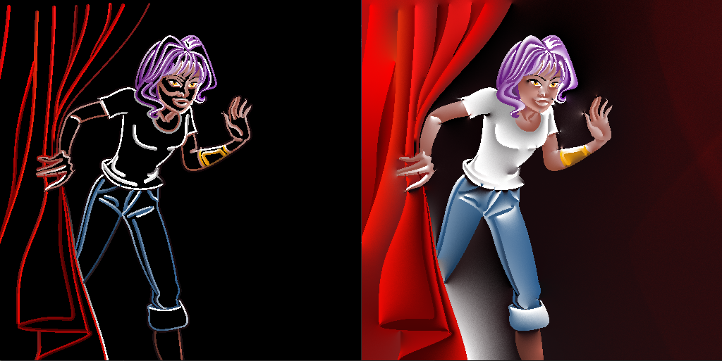

*Behind the curtain diffusion curve image, left the Bézier curves with colors, and right the diffused image, XML provided by Orzan et al. [1].*

While directly solving the partial differential equation is a **correct** approach, Bowers et al. [2] introduce an approximation to the solution using Monte Carlo sampling. This solution is simpler to implement and more similar to other techniques in rendering, which is why we will follow this version. Bowers et al. approximation is to interpret the Bézier curves as 2-dimensional light sources, and the color for each pixel $P$ is the amount of light $L$ it receives from all directions $\phi$:

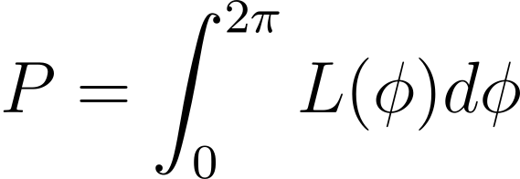

This integral can be estimated using a Monte Carlo strategy, which you saw during the path tracing lectures. We will sample the received light function $L$ at different points and use the samples’ average as the pixel color. Evaluating function $L$ is a visibility test on the curves in the given direction $\phi$.

To guide the implementation of this algorithm, we split it into two main tasks. In the first task, you will implement a simplified problem using circles. In the second task, you will use the experience of Task 1 to implement a version of Bowers et al.’s diffusion curve rendering algorithm.

For this task we have set up a quad covering the screen, giving you exactly 1 fragment per pixel. You can thus use `gl_FragCoord` to get the position of the center of a pixel. This is a similar strategy to what you did in the Physics Simulation deliverable.

We have also set up the C++ code such that you will not have to touch it to complete the task, thus you only have to modify the shader code. But just like previous exercises, you are of course welcome to modify other parts as well.

Note that at the start, you will get many messages stating “WARNING : Could not bind uniform name invalid/unused name”, this is normal and actually implemented by our own framework. All the uniforms are initially unused and thus optimized away, trying to bind a uniform anyway causes this message. If you want to stop the messages, you can edit the `main.cpp` file to not bind these uniforms yet.

## Task 1: Circles

For this task, we do not worry yet about curves and multiple colors. Instead, you receive a list of circles and if a pixel is inside the circle it can receive light from the circle border. Sampling function $L$ from Equation 1 is done using 2-dimensional ray marching, and the rendering of the circles is done in 3 render passes.

The circles are given as a struct :

```
struct Circle {
    vec4 color;
    vec2 position;
    float radius;
};
```

Which are available on the GPU in a Uniform buffer, containing the amount of circles to render, and an array of circles :

```
layout(std140) uniform circleBuffer
{
    int circle_count;
    Circle circles[32];
};
```

*IMPORTANT :* The actual amount of circles is dynamic, the maximum length of the array is arbitrary and required due to limitations from OpenGL 4.1. Hence, `circle_count` is at the most 32.

### Pass 1 : Rasterization

First, we will rasterize the circle representation into a texture. This texture will be used for the ray-marching in the next step.

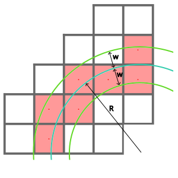

*The light gray grid shows the pixel grid, if the pixel center is within `rasterize_width` (W) of a circle with radius (R) then it should be colored with that circle’s index.*

Each pixel should thus have a value ranging from -1 up to and excluding `circle_count`. Multiple circles can overlap, in this case simply use the circle with the lowest index.

### Intermission : Debugging

As you might have noticed in previous exercises, debugging shader code can be a nuisance as we can not directly observe what is happening inside the shader. In the context of debugging your graphics applications, you might have heard of RenderDoc.

RenderDoc is a program which allows you to inspect any OpenGL GPU resource. This is especially useful in this exercise as we are doing three complicated render passes and only the last one has output. Make sure to play around with RenderDoc, it is more powerful than it seems at first glance.

However, sometimes, for whatever reason, using RenderDoc is not possible, in this case visual debugging is an option, the output of the first two render passes are simply textures, which, with some effort, can be shown using OpenGL. Other debugging techniques are to manipulate the shader, and its inputs, in such a way that it only displays the parts you are working on. To help you with this, a small ImGui debug menu is provided which can be hidden and shown with the `\` key. Initially it contains controls for several variables used in the shaders (and some others) and a way to switch between the intended output (`color_shader`), and the intermediate textures. Feel free to edit the menu and `texture_shader` in any way that might help you. The menu code is located at the end of the render loop, make sure to not remove any option. An example of this menu showing the rasterize texture is shown below.

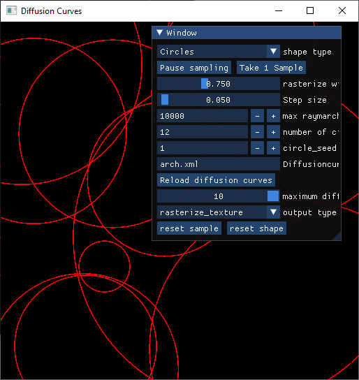

*`rasterize_texture` texture as shown in the in application texture viewer*

### Pass 2.1 : Ray Marching

The second rendering pass is implemented in `shaders/sample_shader.glsl`. We start by implementing ray marching over the just generated texture which is available in `rasterized_texture`. Keep in mind here that texture coordinates are within `[0,1]^2` and *all* input variables are given in screenspace (`[0,511]^2`). The ray marching should be implemented in the `vec2 march_ray(vec2 origin, vec2 direction, float step_size)` function. Given an `origin`, a `direction` and a `step_size`, you should figure out where, if anywhere, the ray intersects a circle and return the intersection. Make sure this algorithm respects `max_raymarch_iter` uniform, and stays within the texture bounds.

### Pass 2.2 : Accumulating samples

Next, we need to actually generate a sample. Begin by marching a ray in a random direction, a pseudo-random number generator is provided in `float get_random_numbers(inout uint seed)`. Make sure the seed is unique across pixels and frames and that the directions should be properly uniformly distributed. NB `vec2(get_random_numbers(seed),get_random_numbers(seed))` is not good enough, think about how the directions would be distributed!

With the intersection we can look up the intersected circle and its color. Remember that `rasterized_texture` stores the circle index. Each sample should be weighted equally, solving the integral in the introduction in the expectation of infinite samples.

The sample should be discarded if the pixel is outside the found circle, which can be checked directly using the circle’s radius, such that we only color the interior of the circle.

Lastly we need to add the sample to the accumulator, the shader output directly *overwrites* the `accumulator_texture` texture, which we will use in the last render pass. Because the output overwrites the texture we need to manually rewrite the previous value, even if our sample was discarded!

### Pass 3 : Render the accumulated samples

The last render pass will be implemented in `shaders/color_shader.glsl`. The `outColor`, should be the weighted average of *all* gathered samples. Think about how we can utilize the four color channels of the `accumulator_texture` to store everything needed for a weighted average. Do not do a running average or worry about potential numerical precision issues, we use a float for every color channel and thus should not run into issues.

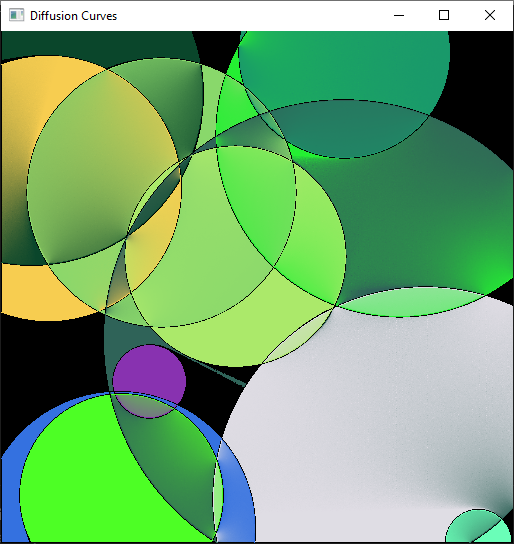

*The result of Task 1, given default settings. In the debug menu you can change the `circle_seed` setting to -1 to get random circles, or use any other seed. You can also reduce or increase the amount of circles*

## Task 2: Diffusion Curves

For the second task, you will render something more interesting than circles. We will now move to the diffusion curves. The description is briefer than for Task 1, but the approach follows the same general idea.

Instead of directly working with Bézier curves, we will approximate them by line segments. We have already subdivided the diffusion curves into line segments for you, according to the algorithm described by Fischer [3].

You might have already noticed the `Line` struct/primitive in the shaders. These lines have a color on the left and right and act like light sources, just like the circles. However, lines have one annoying property, they end! It is ambiguous on what to do there, the more standard vector graphics format SVG has three type line-caps : *butt*, *round* and *square*. You should use *round*.

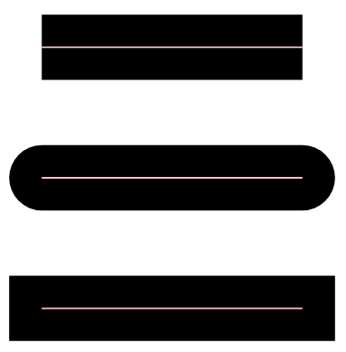

*Butt*, *round* and *square* line-caps.

You should first rasterize lines using round line caps. Next, you should implement a way to sample the rasterized lines. This sampling should take into account from which side the line is hit when ray marching. Instead of each sample having equal weight, they should be weighted inversely by the Euclidean distance between the ray origin $o$ and the intersection point $i$. To avoid division by zero we also add a small epsilon. See the equation below.

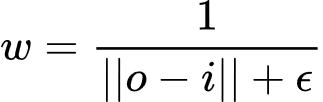

Using different weights means that we do not solve the integral anymore. Instead, we use a heuristically determined weighting of the samples to more closely approximate the diffusion process. The difference of using a constant weight and a weight inversely by the Euclidean distance between the ray origin and the intersection point, is shown below.

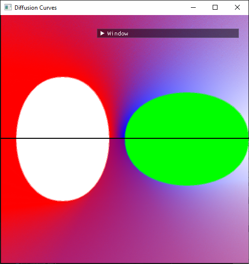

*The difference between using a constant weight (bottom half), and a weight inversely by the Euclidean distance between the ray origin and the intersection point (top half). The XML rendered is `circles2.xml`. The constant weight is mostly purple, while the varying weight still has the color of the lines close by, which is visually closer to the solution of a diffusion equation.*

All of this should be implemented in the shaders already used previously. As a reference, the result for `arch.xml` on maximum subdivision should look like the image below:

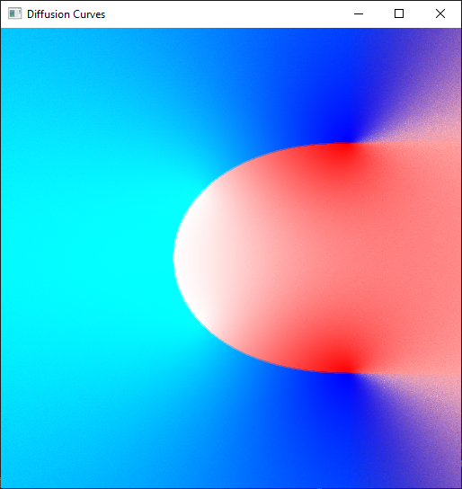

If you want to use other provided xmls you might need to reduce the subdivision level to keep the amount of lines under the maximum amount of 800 lines. This limit is caused by the maximum size of a Uniform Buffer Object. This limit could be eliminated by storing the data in a texture or using SSBOs, but this strategy is beyond the scope of this task, and are also not supported on Apple devices.

### References

[1] A. Orzan, A. Bousseau, P. Barla, H. Winnemöller, J. Thollot, and D. Salesin, ‘Diffusion curves: a vector representation for smooth-shaded images’, Commun. ACM, vol. 56, no. 7, pp. 101–108, Jul. 2013, doi: 10.1145/2483852.2483873.  
[2] J. C. Bowers, J. Leahey, and R. Wang, ‘A Ray Tracing Approach to Diffusion Curves’, Computer Graphics Forum, vol. 30, no. 4, pp. 1345–1352, 2011, doi: 10.1111/j.1467-8659.2011.01994.x.  
[3] K. Fischer, ‘Piecewise Linear Approximation of Bézier Curves’. Accessed: Aug. 12, 2024. [Online]. Available: https://hcklbrrfnn.wordpress.com/wp-content/uploads/2012/08/bez.pdf